# Predicting Movement Class

Rory Murphy

May 17, 2016

# Executive Summary

Using the multitude of new activity monitoring devices has allowed for vast amounts of data related to movement to be collected. This, in turn, has allowed for detailed analysis of these movements to be performed and even goes so far as to allow for the building of prediction models. This report details the analysis and predictive model building for a data set provided by the Weight Lifting Exercise model, kindly licensed for use under the Creative Commons license.

Full citation: Velloso, E.; Bulling, A.; Gellersen, H.; Ugulino, W.; Fuks, H. Qualitative Activity Recognition of Weight Lifting Exercises. Proceedings of 4th International Conference in Cooperation with SIGCHI (Augmented Human ’13) . Stuttgart, Germany: ACM SIGCHI, 2013.

# Data Loading and Cleaning

The training set consists of measurements from various accelerometers on the bodies of participants. This data needs to be loaded and cleaned if necessary.

```r
suppressMessages(library(caret))
fullTraining <- read.csv("pml-training.csv", na.strings = c("NA",
    "#DIV/0!", ""))
indexNZV <- nearZeroVar(fullTraining)
fullTraining <- fullTraining[, -indexNZV]
indexNA <- sapply(fullTraining, function(x) mean(is.na(x))) >
    0.95
fullTraining <- fullTraining[, indexNA == FALSE]
fullTraining <- fullTraining[, -c(1:5)]
rm(indexNZV, indexNA)
```

This now gives cleaned data that has only variables that seem to have a variance with the exercise performed and do not contain any missing data.

# Data Partitioning

The cleaned data set can now be subset using the CARET package and the 60%/40% standard.

```r
inTrain = createDataPartition(fullTraining$classe, p = 0.6, list = FALSE)
training = fullTraining[inTrain, ]
testing = fullTraining[-inTrain, ]
rm(fullTraining, inTrain)
```

This gives a training set with 11776 observations of 54 variables and a testing set with 7846 observations that can be used to validate the model.

# Cross-Validation

It is important to ensure that the remaining variables in the data set are correlated and that they are analysed properly before the model is built.

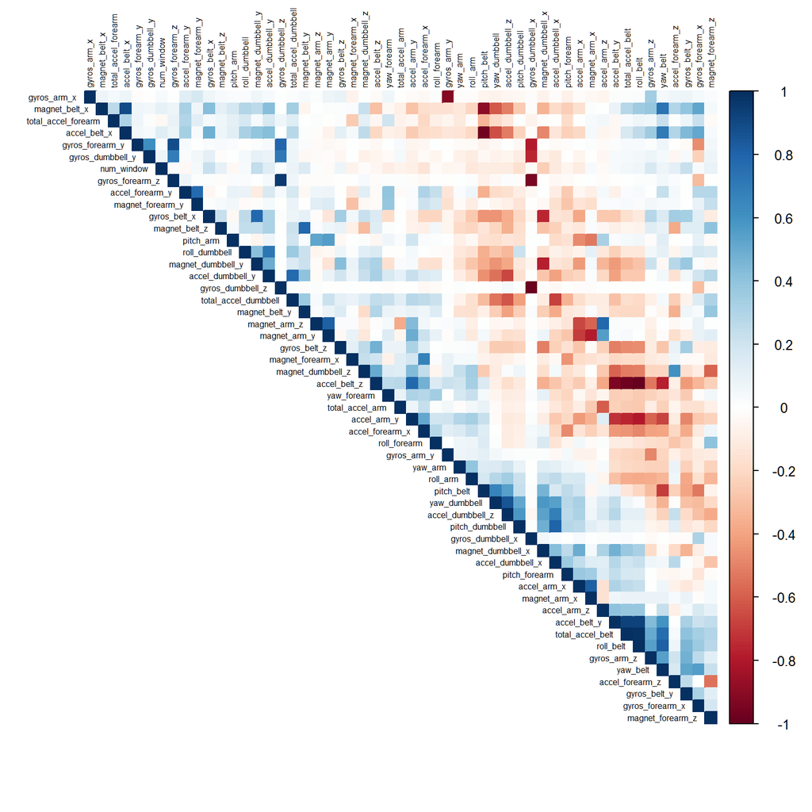

```r
library(corrplot)
correlationMatrix <- cor(training[, -c(54)])
corrplot(correlationMatrix, is.corr = TRUE, type = "upper", method = "color",
    tl.col = rgb(0, 0, 0), tl.cex = 0.5, order = "AOE")
```

# Model Creation

## Decision Tree Model

The first model to be create will be the Decision Tree Model.

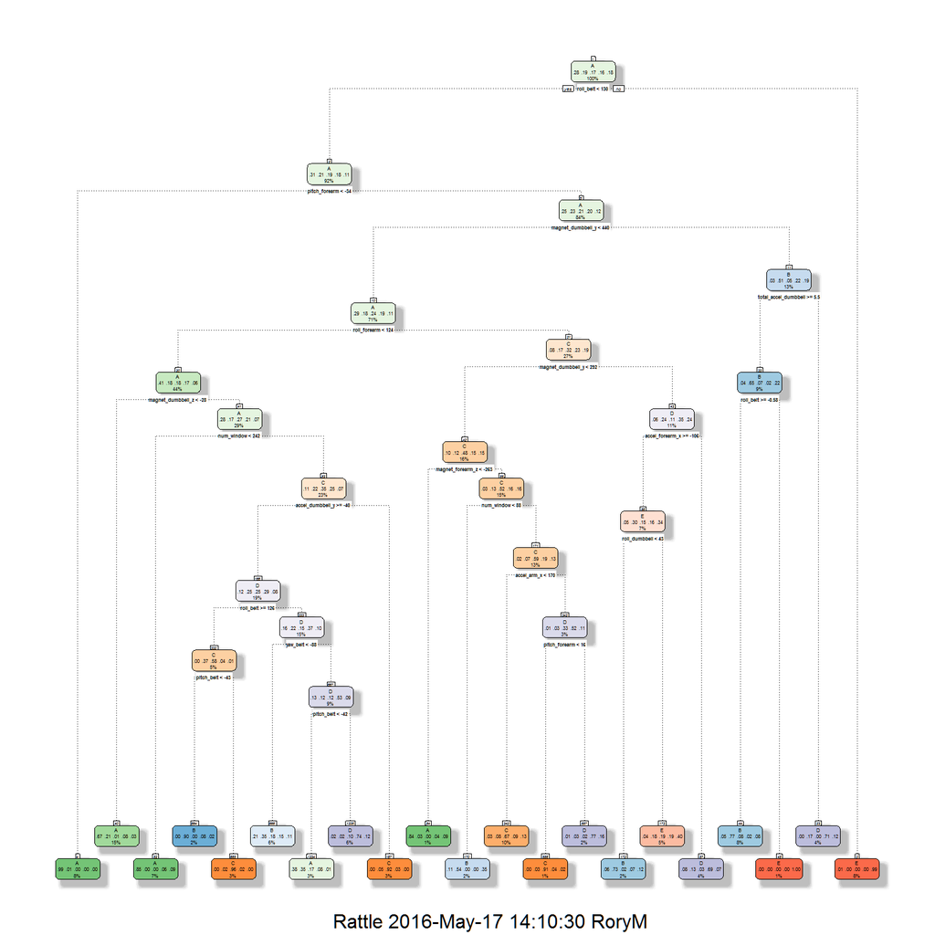

```r
library(rpart)
suppressMessages(library(rattle))
modelFitDT <- rpart(classe ~ ., data = training, method = "class")
fancyRpartPlot(modelFitDT)
```

## Decision Tree Model Analysis

```r
predictionsDT <- predict(modelFitDT, newdata = testing, type = "class")
```

## Random Forest Model

The Random Forest Model can now be created.

```r
library(caret)
library(parallel)
suppressMessages(library(doParallel))
cluster <- makeCluster(detectCores() - 1)
registerDoParallel(cluster)
suppressMessages(library(randomForest))
controlRF <- trainControl(method = "cv", number = 3, verboseIter = FALSE)
modelFitRF <- train(classe ~ ., data = training, method = "rf",
    trControl = controlRF, allowParallel = TRUE)
```

## Random Forest Model Analysis

```r
predictionsRF <- predict(modelFitRF, newdata = testing)
```

## Final Model

# Predicting the Test Cases

Part of this report is to submit the prediction results for the testing file that has been included in the assignment instructions.

```r
finalTesting <- read.csv("pml-testing.csv")
finalPrediction <- predict(modelFitRF, newdata = finalTesting)
finalPrediction
```

```
##  [1] B A B A A E D B A A B C B A E E A B B B
## Levels: A B C D E
```

These are the predicted “classe” values for the exercises described in the final testing file.